# Intro to Bootstrap

## Bootstrap

Bootstrap methods are a class of Monte Carlo methods known as nonparametric Monte Carlo. Bootstrap methods in simple terms are methods of *resampling* observed data to estimate the CDF from which the observed data is supposed to have originate from.

Suppose we observe *independent* samples \(x_1, ..., x_n\) from pdf/pmf \(f\), and whose CDF \(F\) is unobservable. Well, given that \(X = (x_1, ..., x_n)^T\) originates from \(F\), we can use \(X\) to generate the empirical CDF \(F_n\) which is itself an estimate of \(F\).

\[ F_n \to F \text{ as } n \to \infty \]

If we sample (with replacement) another set of \(n\) observations from \(F_n\), we will have \(X^* = (x_1^*, ..., x_n^*)^T\). This new sample \(X^*\) can then generate another empirical CDF, \(F^*_n\) which is another estimate of \(F\).

That is, \(F^*_n\) is a bootstrap estimator of \(F\). We can continue this process of resampling with replacement to obtain samples \(X^*_1,X^*_2, ..., X^*_B\) and \(F^*_{n,1}, F^*_{n,2}, ..., F^*_{n,B}\).

## Bootstrap

In addition to estimating the theoretical CDF \(F\), there may be a statistic of interest \(\theta\) (e.g. mean). We can use bootstrap methods to calculate an empirical distribution of \(\theta\).

From our original sample \(X\) we can calculate estimate \(\hat{\theta}\). Similarly, using the bootstrap samples we can also calcualte estimates for \(\theta\): \(\hat{\theta}^*_1, ..., \hat{\theta}^*_B\).

We can also calculate Bias and make confidence intervals for our estimates.

## Bootstrap Algorithm

A simple bootstrap algorithm for *independent* samples \(X = (x_1, ..., x_n)^T\) is:

To generate *B* bootstrap samples, for *b* in 1, …, *B* do

1. Sample \(x_1, ..., x_n\) with replacement to create sample set \(X^*_b\). Each observation \(x_i\) has a probability of *1/n* of being in the new sample.
2. For \(X^*_b\) calculate \(\hat{\theta}^*_b\)

## Bootstrap Example

We will use the `mtcars` data set to illustrate a simple implementation.

```r
data("mtcars")
mpg = mtcars$mpg
n = length(mpg)
print(mean(mpg))
```

```
## [1] 20.09062
```

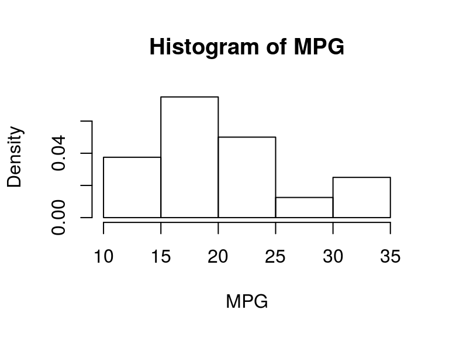

```r
hist(x = mpg, probability = TRUE, xlab = "MPG", main = "Histogram of MPG")
```

## Bootstrap Example

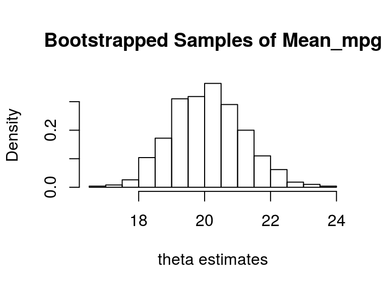

```r
B = 1000 ## number of bootstraps
results = numeric(B) ## vector to hold results
for(b in 1:B){
  i = sample(x = 1:n, size = n, replace = TRUE) ## sample indices
  bootSample = mpg[i] ## get data
  thetaHat = mean(bootSample) ## calculate the mean for bootstrap sample
  results[b] = thetaHat ## store results
}

hist(x = results, probability = TRUE,
     main = "Bootstrapped Samples of Mean_mpg",
     xlab = "theta estimates")
```

## Bootstrap Example

### Precaution

Before enbarking on resampling methods we must ask what variables are *iid* in order to determine a correct bootstrapping approach.

Bootstrap methods are *not* a method of generating new data for, say, a regression setting when observed samples are low.

In the above example, it is assumed that each observation in the `mpg` data set is indpendent and identically distributed from an unknown distribution \(f\).

However, if there were to have existed some autocorrelation structure (as exist in time-series data) then we would need to adjust our resampling methodology to account for this correlation.

When dealing with time-series data, we will use a method called *block bootsrap*.

## Paired Bootstrapping

Let's continue to work with the `mtcars` data set. Say we wanted to make inferences about the linear regression parameters.

```r
library(ggplot2, quietly = TRUE) ## for graphics
mtcars$am <- as.factor(mtcars$am) ## Transmission (0 = automatic, 1 = manual
fit = lm(formula = mpg ~ wt + am, data = mtcars)
data.frame(coefficients = coefficients(fit), CI = confint(fit), check.names = FALSE)
```

```
##             coefficients  CI.2.5 % CI.97.5 %
## (Intercept)  37.32155131 31.074114 43.568989
## wt           -5.35281145 -6.964951 -3.740672
## am1          -0.02361522 -3.184815  3.137584
```

## Paired Bootstrapping

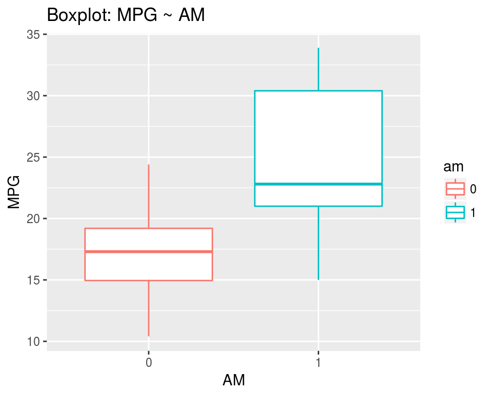

```r
qplot(x = as.factor(am), y = mpg, data = mtcars, geom = "boxplot",
      main = "Boxplot: MPG ~ AM", ylab = "MPG", xlab = "AM",
      colour = am)
```

## Paired Bootstrapping

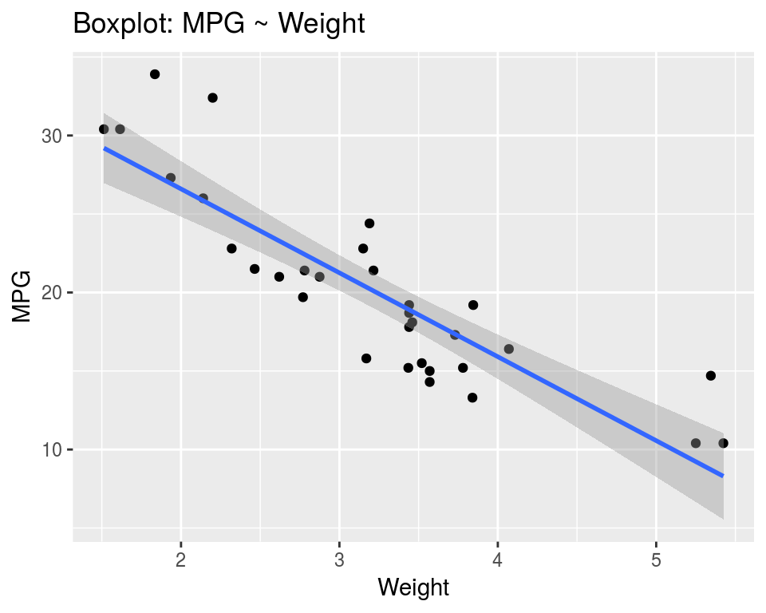

```r
qplot(x = wt, y = mpg, data = mtcars, geom = c("point", "smooth"),
      main = "Boxplot: MPG ~ Weight", ylab = "MPG", xlab = "Weight",
      method = "lm", formula = y~x)
```

## Paired Bootstrapping

```r
## save coefficients
beta_int = coefficients(fit)[1]
beta_wt = coefficients(fit)[2]
beta_am = coefficients(fit)[3]

n = dim(mtcars)[1] ## number of obs in data
B = 1000 ## number of bootstrap samples

results = matrix(data = NA, nrow = B, ncol = 3,
                 dimnames = list(NULL, c("Intercept", "wt", "am")))

## begin bootstrap for-loop
for(b in 1:B){
  i = sample(x = 1:n, size = n, replace = TRUE) ## sample indices
  temp = mtcars[i,] ## temp data set
  temp_model =  lm(formula = mpg ~ wt + am, data = temp) ## train model
  coeff = matrix(data = coefficients(temp_model), ncol = 3) ## get coefficients
  results[b,] = coeff ## save coefficients in matrix
}
```

## Paired Bootstrapping

```r
results <- data.frame(results, check.names = FALSE)

summary(results) ## take a look at the samples
```

```
##    Intercept           wt                am
##  Min.   :27.74   Min.   :-10.930   Min.   :-5.04906
##  1st Qu.:35.31   1st Qu.: -6.095   1st Qu.:-1.19720
##  Median :37.45   Median : -5.397   Median :-0.14538
##  Mean   :37.75   Mean   : -5.494   Mean   :-0.07928
##  3rd Qu.:39.93   3rd Qu.: -4.806   3rd Qu.: 0.91414
##  Max.   :55.78   Max.   : -2.937   Max.   : 6.26362
```

```r
boot_int = results[,"Intercept"]
boot_wt = results[,"wt"]
boot_am = results[,"am"]
```

## Paired Bootstrapping

[figure not shown]

## Paired Bootstrapping

Now we can estimate bias for each parameter estimate. Define Bias as \(Bias(\theta) = E[\theta^*] - \theta\), where in our scenario we have \(Bias(\hat\theta) = E[\hat\theta^*] - \hat\theta\). Our bootstrap bias corrected estimates are then \(\hat\theta_{BC} = \hat\theta - Bias(\hat\theta)\).

```r
bias_int = mean(boot_int - beta_int)
print(bias_int)
```

```
## [1] 0.4303852
```

```r
bias_wt = mean(boot_wt - beta_wt)
print(bias_wt)
```

```
## [1] -0.1414389
```

```r
bias_am = mean(boot_am - beta_am)
print(bias_am)
```

```
## [1] -0.0556616
```

## Paired Bootstrapping

```r
## incorportate our bias into the coefficients
## we now have bias corrected coefficients

intercept = beta_int - bias_int
print(intercept)
```

```
## (Intercept)
##    36.89117
```

```r
wt = beta_wt - bias_wt
print(wt)
```

```
##        wt
## -5.211373
```

```r
am = beta_am - bias_am
print(am)
```

```
##        am1
## 0.03204638
```

## Paired Bootstrapping

Another method for applying the bootstrap approach to building an empirical distribution of \(\hat\beta\) is to bootstrap the residuals. However, bootstrapping the cases is often more robust when there are doubts about a constant variance for the residuals, such as heteroskedasticity. Additionally, paired bootstrap more resembles the original data generation mechanisms.